# Modelos de Regressão para avaliar relação entre variáveis

## 1. Objetivo

O objetivo deste relatório é analisar dados de avaliações de discentes sobre os docentes da Universidade do Texas, em Austin, e validar a hipótese de que a beleza do professor influencia na percepção de competência dos alunos.

Para isto, criaremos modelos de regressão para verificar a relação entre algumas variáveis, descritas mais abaixo.

## 2. Configurações

```r
library(tidyverse)
library(broom)
library(here)
library(lubridate)
source(here::here("code/lib.R"))
theme_set(theme_report())

knitr::opts_chunk$set(tidy = FALSE,
                      fig.width = 6,
                      fig.height = 5)
```

Vamos ler os dados, onde cada linha contém diferentes disciplinas e cada coluna representa as variáveis sobre as disciplinas e os professores.

```r
avaliacoes = read_csv(here::here("data/evals.csv"))
```

## 3. Dados

Descreveremos, abaixo, as variáveis que iremos analisar neste relatório, afim de encontrar possíveis relações entre elas.

- **score:** representa a pontuação média da avaliação do docente. Os valores variam entre 1 (muito insatisfatório) e 5 (excelente) e a distribuição dos dados é relativamente crescente, ou seja, há muitas avaliações com score próximo do valor máximo.

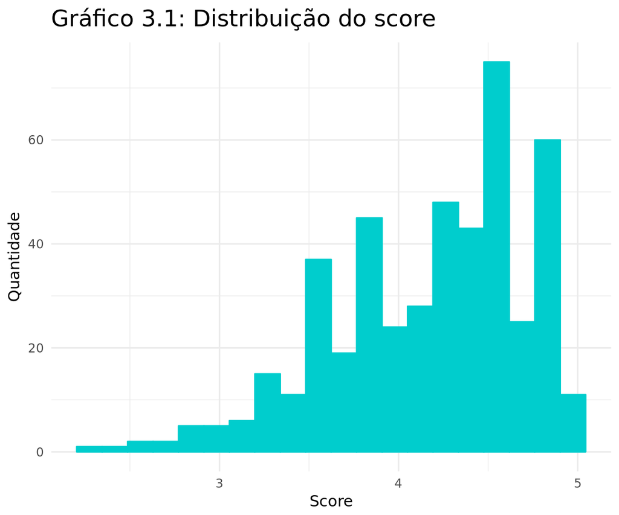

```r
avaliacoes %>%
    ggplot(aes(x = score)) +
    geom_histogram(bins = 20, fill = "cyan3", color = "cyan3") +
    labs(x = "Score", y = "Quantidade",
         title = "Gráfico 3.1: Distribuição do score")
```

- **bty_avg:** representa a média da avaliação da beleza do professor. Os valores variam entre 1.667 e 8.167, onde 1 representa nível de beleza baixo e 10 o nível de beleza mais alto. A distribuição dos dados é relativamente similar em torno dos valores possíveis, apresentando uma leve concentração no valor mediano do intervalo.

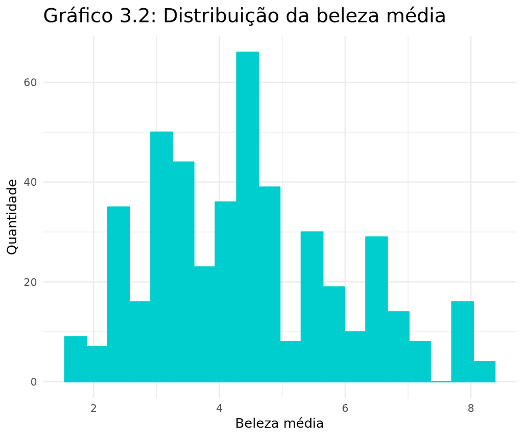

```r
avaliacoes %>%
    ggplot(aes(x = bty_avg)) +
    geom_histogram(bins = 20, fill = "cyan3", color = "cyan3") +
    labs(x = "Beleza média", y = "Quantidade",
         title = "Gráfico 3.2: Distribuição da beleza média")
```

- **age:** representa a idade do professor e seus valors variam entre 29 e 73, como mostrado no gráfico logo abaixo.

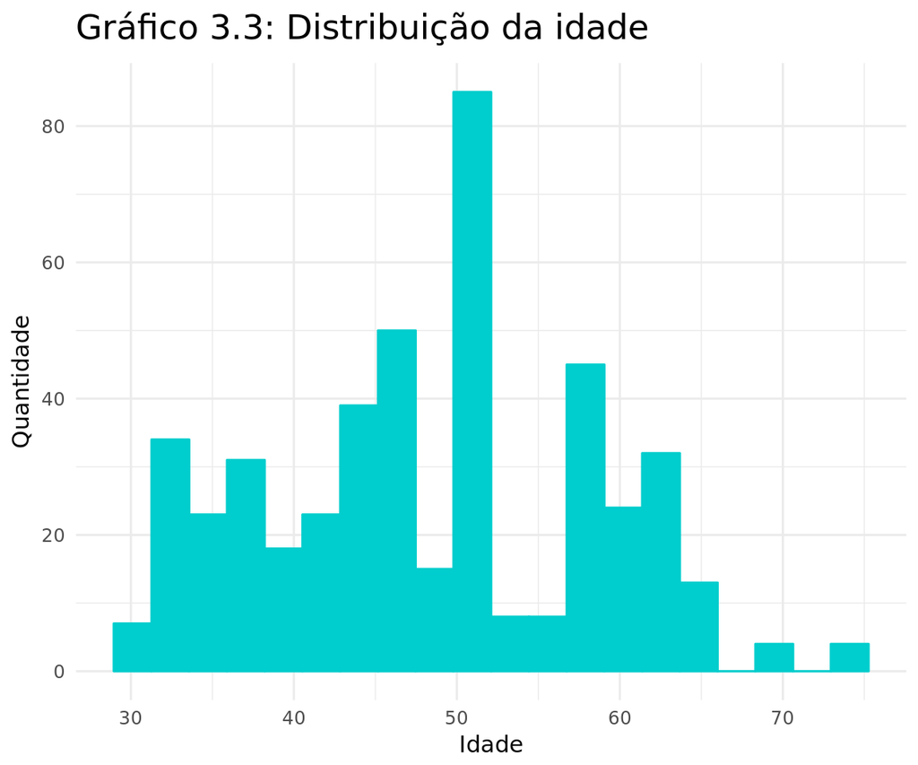

```r
avaliacoes %>%
    ggplot(aes(x = age)) +
    geom_histogram(bins = 20, fill = "cyan3", color = "cyan3") +
    labs(x = "Idade", y = "Quantidade",
         title = "Gráfico 3.3: Distribuição da idade")
```

- **pic_outfit:** representa o tipo da roupa que o professor usava na foto avaliada, sendo os possíveis valores informal ou formal, sendo não formais a maioria das roupas que os professores usavam, como exibido no gráfico abaico.

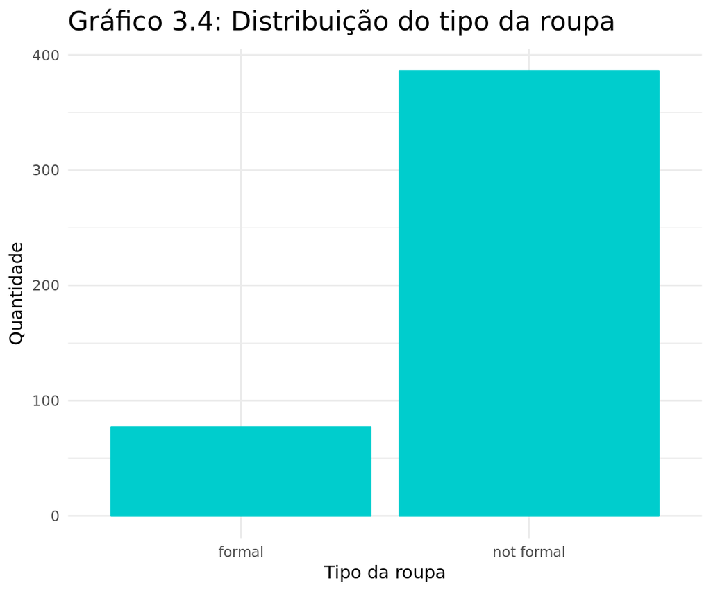

```r
avaliacoes %>%
    group_by(pic_outfit) %>%
    summarise(n = n()) %>%
    ggplot(aes(x = pic_outfit, y = n)) +
    geom_col(fill = "cyan3", color = "cyan3") +
    labs(x = "Tipo da roupa", y = "Quantidade",
         title = "Gráfico 3.4: Distribuição do tipo da roupa")
```

- **pic_color:** representa a cor da foto avaliada do professor, sendo os possíveis valores colorida ou preto&branco. A distribuição dos valores é similar ao gráfico anterior, apresentando mais professores com fotos coloridas.

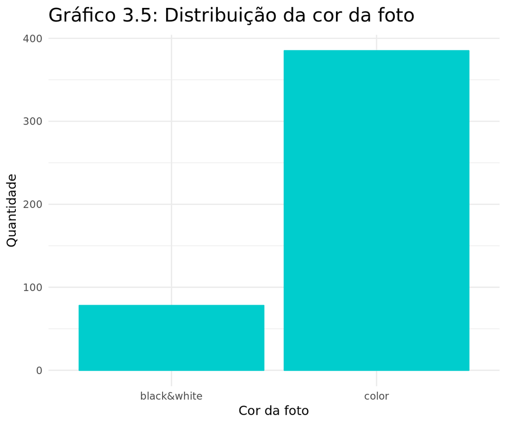

```r
avaliacoes %>%
    group_by(pic_color) %>%
    summarise(n = n()) %>%
    ggplot(aes(x = pic_color, y = n)) +
    geom_col(fill = "cyan3", color = "cyan3") +
    labs(x = "Cor da foto", y = "Quantidade",
         title = "Gráfico 3.5: Distribuição da cor da foto")
```

## 4. Análise dos dados

### 4.1. Modelo de regressão linear simples

A princípio, verificaremos a relação entre beleza e score. Para isso, vejamos abaixo a distribuição desses dados.

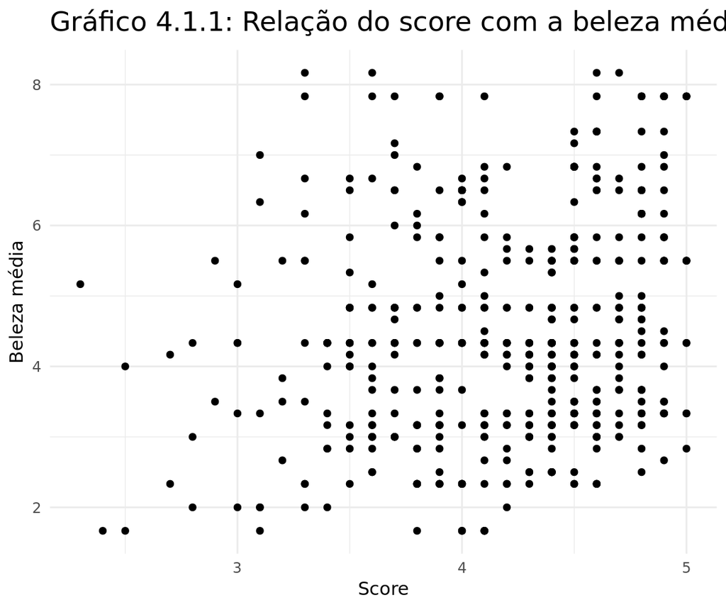

```r
avaliacoes %>%
  ggplot(aes(x = score, y = bty_avg)) +
  geom_point() +
    labs(x = "Score", y = "Beleza média",
         title = "Gráfico 4.1.1: Relação do score com a beleza média")
```

Parece que não existe uma relação linear forte entre as duas variáveis analisadas, pois não vemos nenhum padrão. Mas vamos criar um modelo para verificar:

```r
set.seed(1)
modelo_score_beleza = lm(score ~ bty_avg, data = avaliacoes)

tidy(modelo_score_beleza, conf.int = TRUE, conf.level = 0.95)
```

```
##          term   estimate  std.error statistic       p.value   conf.low
## 1 (Intercept) 3.88033795 0.07614297 50.961212 1.561043e-191 3.73070764
## 2     bty_avg 0.06663704 0.01629115  4.090382  5.082731e-05 0.03462292
##    conf.high
## 1 4.02996827
## 2 0.09865116
```

```r
glance(modelo_score_beleza)
```

```
##    r.squared adj.r.squared     sigma statistic      p.value df    logLik
## 1 0.03502226    0.03292903 0.5348351  16.73123 5.082731e-05  2 -366.2225
##        AIC      BIC deviance df.residual
## 1 738.4449 750.8581 131.8684         461
```

Regressão linear simples foi utilizada para analisar se a **beleza dos professores** tem uma associação significativa e relevante com a **avaliação dos professores** (feita por discentes). Os resultados da regressão indicam que um modelo com 1 preditor no formato $score = 3.88 + 0.07 * beleza$ explica apenas 3,5% da variância da variável de resposta (R2 = 0.0350). $beleza$, medida como a média da avaliação da beleza do professor para cada disciplina, com valores entre [1.667, 8.167], tem uma relação significativa com o erro b = [0,03; 0,1], IC com 95%. O aumento de 1 unidade de $beleza$ produz uma mudança de 0.07 na avaliação dos professores ($score$), o que não se mostra tão relevante.

Estes resultados nos induzem a rejeitar a hipótese de que a beleza do professor influencia na percepção de competência dos alunos.

#### 4.2. Modelo de regressão linear multivariado

Como não encontramos relação relevante entre beleza e score, através do modelo anterior, definiremos outras variáveis que podem influenciar na definição de beleza e consequentemente na percepção de competência dos alunos, por exemplo, a idade dos professores, o tipo da roupa do professor na foto avaliada e a cor da foto avaliada.

Supõe-se que, quanto mais jovem seja um professor, mais atraente ele será, aumentando, possivelmente, a sua avaliação. É possível que a foto informal e a foto colorida também influenciem positivamente na avaliação, então, vamos verificar:

```r
set.seed(1)
modelo_score_beleza2 = lm(score ~ bty_avg + age + pic_outfit + pic_color, data = avaliacoes)

tidy(modelo_score_beleza2, conf.int = TRUE, conf.level = 0.95)
```

```
##                   term     estimate   std.error  statistic      p.value
## 1          (Intercept)  4.334507606 0.214925640 20.1674757 3.364279e-65
## 2              bty_avg  0.046185732 0.018015696  2.5636385 1.067627e-02
## 3                  age -0.004068407 0.002735546 -1.4872377 1.376401e-01
## 4 pic_outfitnot formal -0.032540712 0.068929494 -0.4720869 6.370896e-01
## 5       pic_colorcolor -0.168269153 0.069626634 -2.4167354 1.605028e-02
##       conf.low   conf.high
## 1  3.912144959  4.75687025
## 2  0.010782059  0.08158941
## 3 -0.009444185  0.00130737
## 4 -0.167997997  0.10291657
## 5 -0.305096428 -0.03144188
```

```r
glance(modelo_score_beleza2)
```

```
##    r.squared adj.r.squared     sigma statistic      p.value df    logLik
## 1 0.05090876    0.04261975 0.5321486   6.14172 8.051796e-05  5 -362.3795
##        AIC      BIC deviance df.residual
## 1 736.7591 761.5854 129.6974         458
```

Assim como a média da avaliação de beleza, as variáveis $idade$, $tipoDaFoto$ e $corDaFoto$ não apresentam relevância na variância da avaliação dos professores. O modelo de regressão linear multivariada, gerado com estas 4 variáveis, no formato $avaliacao = 4.33 + 0.05*beleza - 0.004*idade - 0.03*tipoDaFoto - 0.17*corDaFoto$ explica apenas 5,09% da variância da variável de resposta (R2 = 0.0509), 2% a mais que o modelo anterior, aproximadamente. $beleza$, medida como a média da avaliação da beleza do professor para cada disciplina, com valores entre [1.667, 8.167], tem uma relação significativa com o erro b = [0,01; 0,08]; $idade$, medida como a idade de cada professor, com valores entre [29, 73], tem uma relação *não significativa* com o erro b = [-0,01; 0,001]; $tipoDaFoto$, medida como a roupa do professor na foto avaliada, com os valores formal (0) e informal (1), tem uma relação *não significativa* com o erro b = [-0,17; 0,1], e, por fim, $corDaFoto$, medida como a cor da foto avaliada do professor, com os valores colorida (1) e preta&branco (0), tem uma relação significativa com o erro b = [-0,3; -0,03], todos os IC com 95%. O aumento de 1 unidade de $beleza$ produz um aumento de 0.05 na avaliação dos professores ($score$), enquanto que $idade$, $tipoDaFoto$ e $corDaFoto$ alteram -0.004, -0.03 e -0.17, respectivamente.

Assim, todas as hipóteses sobre as variáveis deste modelo também foram rejeitadas, porque elas apresentam fraca relevância, apesar de duas delas (beleza média e cor da foto) ter significância, com a variável de resposta.

## 5. Conclusões

A partir dos modelos de regressão criados, percebemos que a beleza não apresenta relação relevante na pontuação da avaliação dos professores, feita pelos discentes.